# me observe from the above table, that 400 people planned to purchase and actually placed an order for 'A'

# Explore the data

```python
company.dtypes
```

```
Startup           object
Product           object
Funding           object
Event             object
Result            object
OperatingState    object
dtype: object
```

```python
company.isna().sum()
```

```
Startup             0
Product             6
Funding           214
Event               0
Result              0
OperatingState      0
dtype: int64
```

Turns out we do not have company of funding by all the companies

- We would need need it to perform the first task, hence we will have to ignore the companies of which we do not have company for the funds they raised

```python
df1= company.dropna().copy(deep=True)   # drop the rows which have no company for funding
```

```python
df1['Funding'].sample(5)
```

```
31        $24M
447      $7.4M
40      $50.9M
330      $9.2M
214    $755.9K
Name: Funding, dtype: object
```

- We do not have absolute numbers to directly use in our tests
- The values need some pre-processing
- We will strip the values of the dollar sign and the abbreviations
- First we will have to check all the various abbreviations that the numbers are represented by, then based on the abbreviation we have to bring those numbers on the same scale

```python
df1.loc[:,'Funding_in_million'] = df1['Funding'].apply(lambda x: float(x[1:-1])/1000 if x[-1] == 'K' else (float(x[1:-1])*1000 if x[-1] == 'B' else float(x[1:-1])))
```

```python
df1.sample(3)
```

|  | Startup | Product | Funding | Event | Result | OperatingState | Funding_in_million |
| --- | --- | --- | --- | --- | --- | --- | --- |
| 184 | Fidesmo | fidesmo.com | $790.6K | Disrupt NYC 2014 | Contestant | Operating | 0.7906 |
| 141 | Desmos | desmos.com | $900K | Disrupt NYC 2011 | Contestant | Operating | 0.9000 |
| 59 | BioBots | biobots.io | $2.8M | Disrupt NY 2015 | Finalist | Operating | 2.8000 |

- Run the above cell a couple of times to quickly verify the values
- We have brought the data to a usable form for analysis

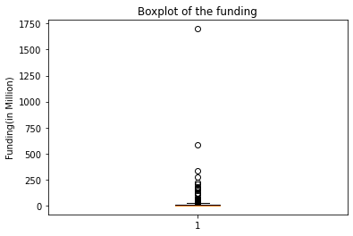

```python
%matplotlib inline
from matplotlib import pyplot as plt

plot = plt.boxplot(df1.Funding_in_million)
plt.title('Boxplot of the funding')
plt.ylabel("Funding(in Million)")

plt.show()
```

- There are significant outliers in the data
- For the purpose of this test, we shall remove them

```python
upper_fence = plot['caps'][1].get_data()[1][1]   # we can use the values from the box plot itself to get the upper fence
upper_fence
```

```
22.0
```

```python
print(f'Number of outliers = {len(df1[df1.Funding_in_million > upper_fence])}')

df1[df1.Funding_in_million > upper_fence]
```

```
Number of outliers = 60
```

|  | Startup | Product | Funding | Event | Result | OperatingState | Funding_in_million |
| --- | --- | --- | --- | --- | --- | --- | --- |
| 6 | 8 Securities | 8securities.com | $29M | Disrupt Beijing 2011 | Finalist | Operating | 29.0 |
| 31 | Anyclip | anyclip.com | $24M | TC50 2009 | Finalist | Operating | 24.0 |
| 40 | Artsy | artsy.net | $50.9M | Disrupt NYC 2010 | Contestant | Operating | 50.9 |
| 49 | Badgeville | badgeville.com | $40M | Disrupt SF 2010 | Finalist | Acquired | 40.0 |
| 56 | Betterment | betterment.com | $205M | Disrupt NYC 2010 | Finalist | Operating | 205.0 |
| 108 | Clickable | clickable.com | $32.5M | TC40 2007 | Finalist | Acquired | 32.5 |
| 113 | Cloudflare | cloudflare.com | $182.1M | Disrupt SF 2010 | Runner up | Operating | 182.1 |
| 128 | Credit Sesame | creditsesame.com | $35.4M | Disrupt SF 2010 | Contestant | Operating | 35.4 |
| 130 | CrowdFlower Inc. | crowdflower.com | $38M | TC50 2009 | Contestant | Operating | 38.0 |
| 132 | Cubic Telecom | cubictelecom.com | $37.1M | TC40 2007 | Contestant | Operating | 37.1 |
| 138 | DataSift | datasift.com | $72M | Disrupt SF 2010 | Finalist | Operating | 72.0 |
| 139 | DataXu | dataxu.com | $64M | TC50 2009 | Contestant | Operating | 64.0 |
| 154 | Dropbox | dropbox.com | $1.7B | TC50 2008 | Contestant | Operating | 1700.0 |
| 166 | Enigma | enigma.io | $34.6M | Disrupt NYC 2013 | Winner | Operating | 34.6 |
| 172 | EverythingMe | everything.me | $35.5M | Disrupt NYC 2011 | Contestant | Closed | 35.5 |
| 179 | Famo.us | famo.us | $30.1M | Disrupt SF 2012 | Contestant | Operating | 30.1 |
| 180 | Farmigo | farmigo.com | $26M | Disrupt SF 2011 | Finalist | Operating | 26.0 |
| 188 | Fitbit | fitbit.com | $66M | TC50 2008 | Finalist | Ipo | 66.0 |
| 191 | Flock | flock.com | $28.3M | TC40 2007 | Contestant | Acquired | 28.3 |
| 209 | Getaround | getaround.com | $103M | Disrupt NYC 2011 | Winner | Operating | 103.0 |
| 213 | Gild | gild.com | $25.9M | Disrupt SF 2010 | Contestant | Acquired | 25.9 |
| 215 | Glide | glide.me | $36.5M | Disrupt NYC 2013 | Audience choice | Operating | 36.5 |
| 225 | Grockit | grockit.com | $44.7M | TC50 2008 | Finalist | Acquired | 44.7 |
| 231 | HackerRank | hackerrank.com | $24.2M | Disrupt SF 2012 | Contestant | Operating | 24.2 |
| 271 | Ionic Security | ionicsecurity.com | $122.4M | Disrupt SF 2012 | Contestant | Operating | 122.4 |
| 276 | IZEA | izea.com | $34.9M | Disrupt NYC 2010 | Contestant | Ipo | 34.9 |
| 279 | Jiff | jiff.com | $67.8M | Disrupt SF 2011 | Contestant | Acquired | 67.8 |
| 282 | Kaltura | kaltura.com | $166.1M | TC40 2007 | Audience choice | Operating | 166.1 |
| 302 | Layer | layer.com | $42.1M | Disrupt SF 2013 | Winner | Operating | 42.1 |
| 305 | LearnVest | learnvest.com | $69M | TC50 2009 | Contestant | Acquired | 69.0 |
| 313 | LiveIntent | liveintent.com | $65.1M | Disrupt NYC 2010 | Audience choice | Operating | 65.1 |
| 325 | Lystable | lystable.com | $25.1M | Disrupt London 2015 | Finalist | Operating | 25.1 |
| 346 | Mint | mint.com | $31.8M | TC40 2007 | Winner | Acquired | 31.8 |
| 389 | OrderWithMe | orderwithme.com | $37M | Disrupt Beijing 2011 | Winner | Operating | 37.0 |
| 393 | Osmo | playosmo.com | $38.5M | Disrupt SF 2013 | Contestant | Operating | 38.5 |
| 394 | Ossia | ossia.com | $25.5M | Disrupt SF 2013 | Runner up | Operating | 25.5 |
| 398 | Owlet Baby Care | owletcare.com | $24M | Hardware Battlefield 2014 | Runner up | Operating | 24.0 |
| 427 | Postmates | postmates.com | $278M | Disrupt SF 2011 | Contestant | Operating | 278.0 |
| 432 | Prism Skylabs | prism.com | $24M | Disrupt SF 2011 | Runner up | Operating | 24.0 |
| 435 | PubMatic | pubmatic.com | $63M | TC40 2007 | Contestant | Operating | 63.0 |
| 460 | Roadie | roadie.com | $25M | Disrupt NYC 2014 | Audience choice | Operating | 25.0 |
| 471 | SeatGeek | seatgeek.com | $160M | TC50 2009 | Contestant | Operating | 160.0 |
| 546 | StyleSeat | styleseat.com | $40M | Disrupt NYC 2011 | Contestant | Operating | 40.0 |
| 555 | Symphony Commerce | symphonycommerce.com | $47.4M | Disrupt NYC 2011 | Contestant | Operating | 47.4 |
| 560 | Talkdesk | talkdesk.com | $24.5M | Disrupt NYC 2012 | Contestant | Operating | 24.5 |
| 581 | TouchPal | touchpal.com | $25M | Disrupt Beijing 2011 | Finalist | Operating | 25.0 |
| 593 | TrueCar | truecar.com | $332.4M | TC50 2008 | Contestant | Ipo | 332.4 |
| 598 | UberConference | uberconference.com | $35M | Disrupt NYC 2012 | Winner | Operating | 35.0 |
| 606 | Upwork | upwork.com | $168.8M | TC50 2009 | Audience choice | Operating | 168.8 |
| 615 | VideoSurf | videosurf.com | $28M | TC50 2008 | Contestant | Acquired | 28.0 |
| 625 | Voxy | voxy.com | $30.8M | Disrupt SF 2010 | Contestant | Operating | 30.8 |
| 643 | Xobni | yahoo.com | $41.8M | TC40 2007 | Contestant | Acquired | 41.8 |
| 644 | Yammer | yammer.com | $142M | TC50 2008 | Winner | Acquired | 142.0 |
| 647 | Yext | yext.com | $117.8M | TC50 2009 | Contestant | Ipo | 117.8 |
| 649 | YouNow | younow.com | $26M | Disrupt SF 2011 | Contestant | Operating | 26.0 |
| 650 | YourMechanic | yourmechanic.com | $28M | Disrupt SF 2012 | Winner | Operating | 28.0 |
| 654 | ZEFR | zefr.com | $62.1M | Disrupt NYC 2010 | Contestant | Operating | 62.1 |
| 656 | Zenefits | zenefits.com | $583.6M | Disrupt NYC 2013 | Finalist | Operating | 583.6 |
| 659 | Zocdoc | zocdoc.com | $223M | TC40 2007 | Contestant | Operating | 223.0 |
| 661 | Zumper | zumper.com | $31.5M | Disrupt SF 2012 | Finalist | Operating | 31.5 |

- The above 60 records are of companies that have been funded excessively in comparision to the others in the pool
- Let's see the distribution without these outliers

```python
df1.drop(df1[df1.Funding_in_million > upper_fence].index, inplace = True)
```

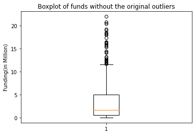

```python
plot = plt.boxplot(df1.Funding_in_million)
plt.title('Boxplot of funds without the original outliers')
plt.ylabel("Funding(in Million)")
plt.show()
```